# Students Data Analysis

#### 6. (10p) Create a two sample hypothesis to compare mean salaries of the students graduated from “political sciences” and “economics and finance”. Test it in 95% confidence level.

To start, it always helps to plot things!!!

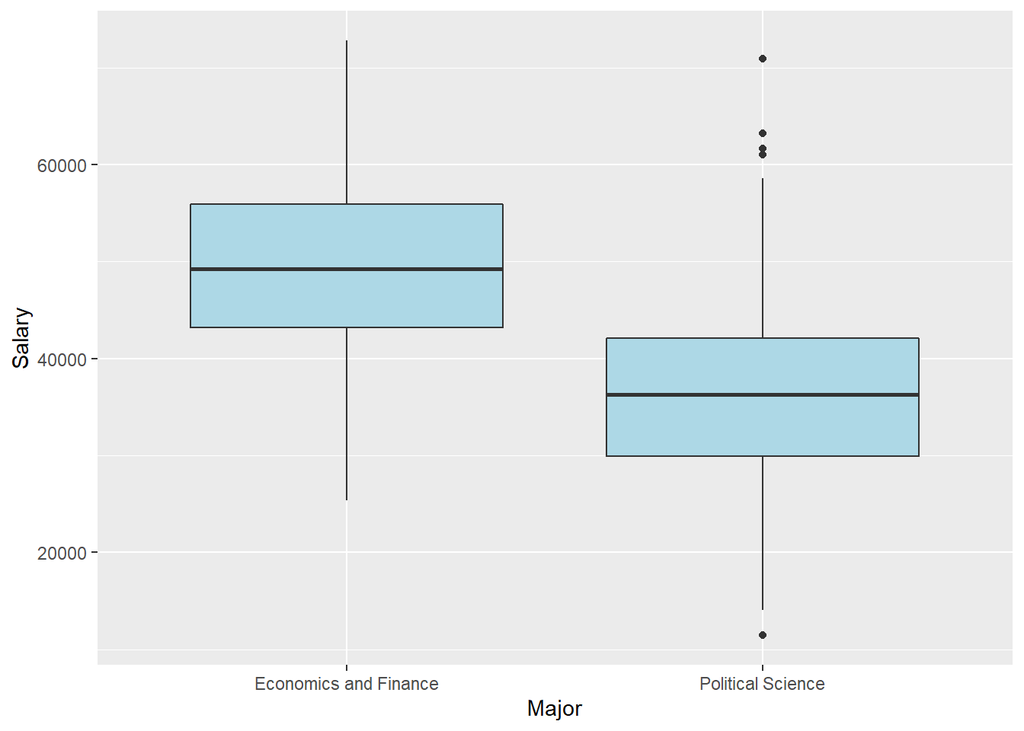

```r
# Get subset of students who have salary
sdata <- subset(students, !is.na(salary))
sdata <- subset(sdata, major=="Political Science" | major=="Economics and Finance")

# Create boxplot showing how salary varies based on major
qplot(x = major, y = salary,
      geom = "boxplot", data = sdata,
      xlab = "Major",
      ylab = "Salary",
      fill = I("lightblue"))
```

This plot suggests that Major is associated with Salary.

Let’s compute a summary table

```r
aggregate(salary ~ major,
          data = sdata,
          FUN = function(x) {c(mean = mean(x),
                               se = sd(x) / sqrt(length(x)))})
```

```
##                   major salary.mean  salary.se
## 1 Economics and Finance  49696.1719   494.6344
## 2     Political Science  36390.2733   542.4583
```

This difference is looking quite significant.

Let’s visualize it.

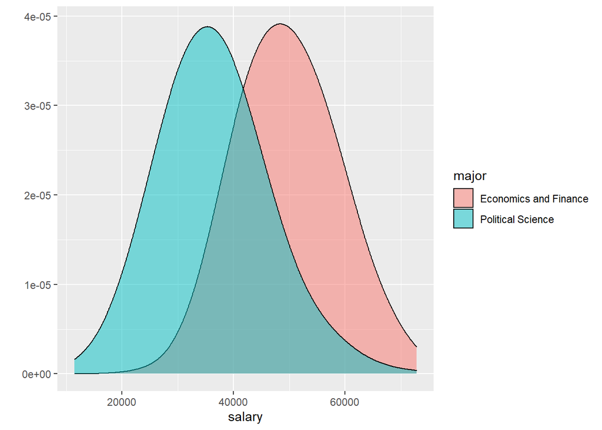

```r
# Density plots
qplot(fill = major,
      x = salary,
      data = sdata,
      geom = "density",
      alpha = I(0.5),
      adjust = 2
      )
```

Let’s check if the populations have the same variance.

```r
x <- subset(sdata, major=="Political Science")$salary
y <- subset(sdata, major=="Economics and Finance")$salary
var.test(x, y)
```

```
##
##  F test to compare two variances
##
## data:  x and y
## F = 1.1783, num df = 288, denom df = 294, p-value = 0.1622
## alternative hypothesis: true ratio of variances is not equal to 1
## 95 percent confidence interval:
##  0.936057 1.483535
## sample estimates:
## ratio of variances
##           1.178257
```

As p-value > 0.05, the null hypothesis is not rejected and the variances are accepted as equal.

Checking assumptions: The two samples are random and independent. As the sample size is large enough, normality is not important. The variances are accepted as equal.

```r
t.test(x=x, y=y, alternative = "two.sided", var.equal = TRUE,
       conf.level = 0.95)
```

```
##
##  Two Sample t-test
##
## data:  x and y
## t = -18.14, df = 582, p-value < 2.2e-16
## alternative hypothesis: true difference in means is not equal to 0
## 95 percent confidence interval:
##  -14746.52 -11865.28
## sample estimates:
## mean of x mean of y
##  36390.27  49696.17
```

As p-value < 0.05, the null hypothesis is rejected. We can conclude that there is statistically significant difference between “Political science” and “Economics and Finance” students salary.

#### 7. (20p) Create working functions requested in RLecture4 page 7-8. Implement and demonstrate them using above dataset.

Correlation analyzer function is implemented and used above. Missing Value Replacer with 10% trimmed mean function is implemented and used below.

```r
missingValueReplacer <- function(vector, trim=0.10){
  temp <- subset(vector, !is.na(vector))
  temp <- sort(temp)
  len <- length(temp)
  start <- round(len * trim + 1)
  end <- len - (start - 1)
  s <- 0
  for (i in start:end) {
    s <- s + temp[i]
  }
  average = s/(end-start + 1)

  for(i in 1:length(vector)) {
    if(is.na(vector[i])){
      vector[i] <- average
    }
  }

  vector
}

as.data.frame(head(students$salary, 20))
```

```
##    head(students$salary, 20)
## 1                         NA
## 2                         NA
## 3                         NA
## 4                         NA
## 5                         NA
## 6                         NA
## 7                         NA
## 8                         NA
## 9                         NA
## 10                        NA
## 11                  45254.11
## 12                        NA
## 13                  40552.79
## 14                  27007.03
## 15                        NA
## 16                        NA
## 17                  33969.16
## 18                        NA
## 19                        NA
## 20                        NA
```

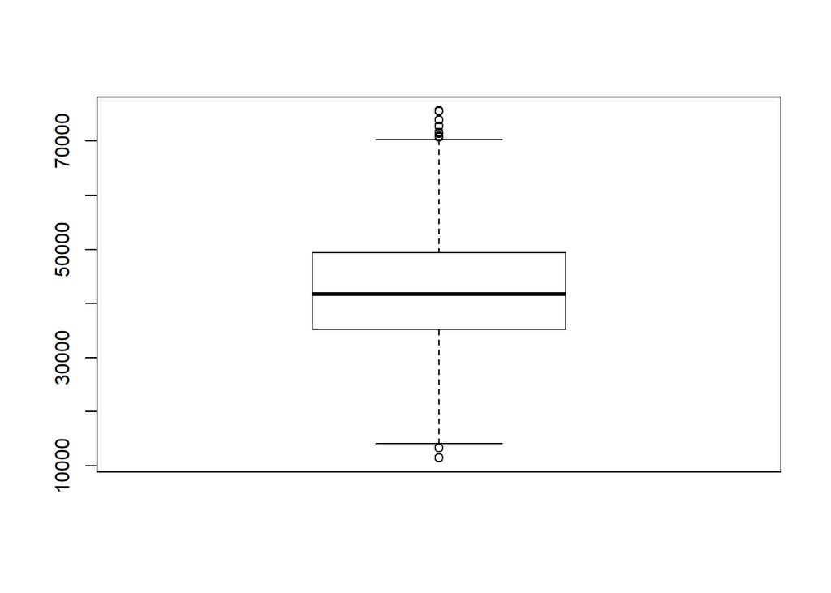

```r
boxplot(students$salary)
```

Now let’s see the above data and boxplot after applying missing value replacer function.

```r
students$salary <- missingValueReplacer(students$salary)
as.data.frame(head(students$salary, 20))
```

```
##    head(students$salary, 20)
## 1                   42224.47
## 2                   42224.47
## 3                   42224.47
## 4                   42224.47
## 5                   42224.47
## 6                   42224.47
## 7                   42224.47
## 8                   42224.47
## 9                   42224.47
## 10                  42224.47
## 11                  45254.11
## 12                  42224.47
## 13                  40552.79
## 14                  27007.03
## 15                  42224.47
## 16                  42224.47
## 17                  33969.16
## 18                  42224.47
## 19                  42224.47
## 20                  42224.47
```

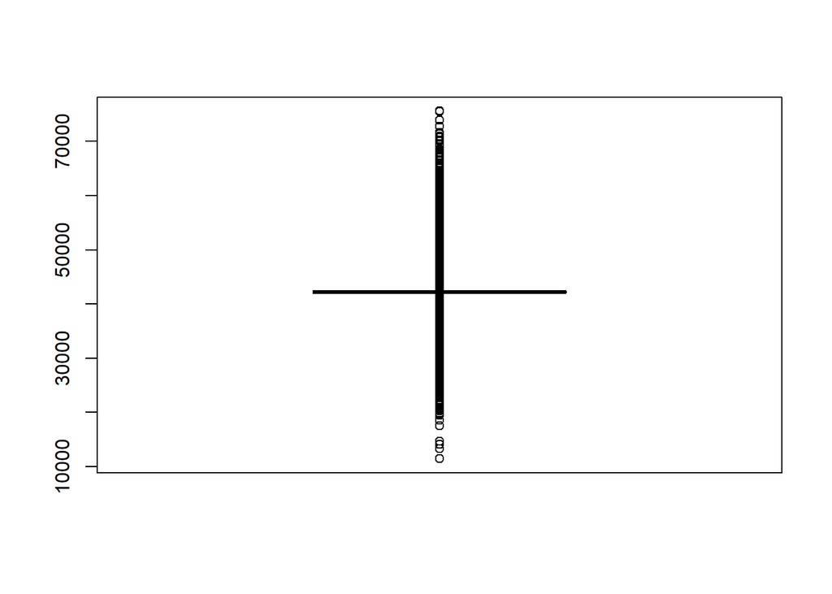

```r
boxplot(students$salary)
```